# Prosper Loan Analysis

## by Franklin Adjei

## Investigation Overview

> For this presentation, I focus on the distribution of the features and the relationships that exist between them and Prosper Score(the variable of interest).

## Dataset Overview

> The Prosper loan dataset comprises of 113937 loan entries with 81 attributes on each loan, including loan amount, borrower rate (or interest rate), current loan status, borrower income, and many others, from the year 2009-2014. There are two main categories:
> - Borrower information: Basic information of the borrowers such as annual income, employment status, interest rate, loan status, etc.
> - Loan performance information: Metrics evaluating the risk associated with the loans such as Prosper score and bank card utilization, etc. There were some elements that need to be fixed, in order to create interesting and trustworthy analyses and visualizations.

## Distribution of Prosper Score Column and Loan Status column

The Prosper score ranges from 1 to 11. There are a significant number of outstanding loans yet to be cleared. Moreover, `33.4%` of loans have been completed and an insignificant number of loans are past due as seen in the plot.

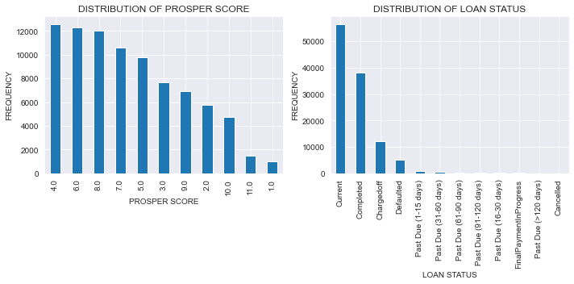

## Comparing the distribution of the EmploymentStatus column, IncomeRange column, LoanStatus column, and Number of Prosper loans by the ProsperScore column.

Borrowers with higher income range tend to have relatively higher Prosper score. Also, the Employment status and Loan status greatly influenced the Prosper score.

One of the interesting findings I discovered is that most of the borrowers with `3, 4, 5, and 7` loan applications had higher Prosper score.

[figure not shown]

## Explore the relationships between the Prosper Score and other numerical columns using Seaborn PairGrid method.

```
A PAIR PLOT TO ESTABLISH RELATIONSHIPS AMONG NUMERICAL COLUMNS
```

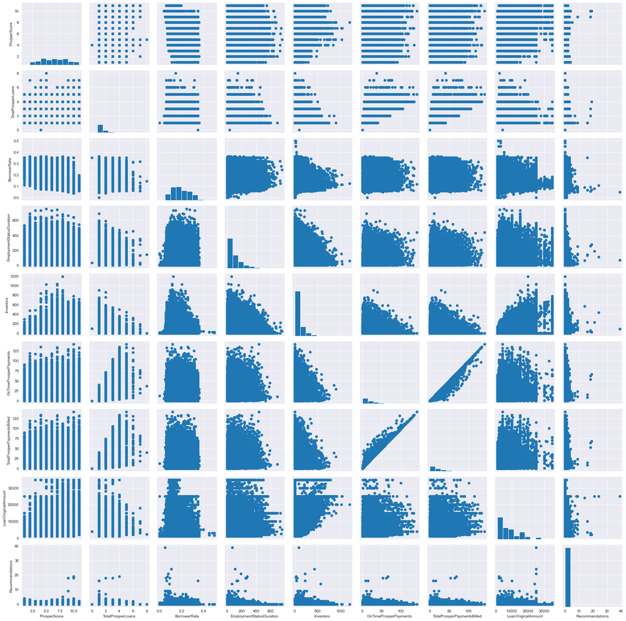